# Group#2 Final

Group 2

4/30/2018

# Introduction

Our project team has obtained a data set containing 2,571 observations with each observation representing a batch of beverages that were produced. Variables included in the data set provide information on the manufacturing process that resulted in the creation of each batch. It is our task to use the 32 predictor variables to develop a model which can be used to predict the PH level in a batch. We have been provided with a training and test set.

The objective is to build multiple models on the training data and then we will then run analysis to determine which model performed best.

## Team Members (alphabetical)

- Brian Kreis
- Bin Lin
- Chris Martin
- Asher Myers

# Dataset

For reproducibility of the results, the data was loaded to and accessed from a Github repository.

# Data Exploration and Statistic Measures

The purpose of the data exploration and statistic measures phase is to understand the data to determine how to process the dataset for modelling.

## Missing and Zero Values

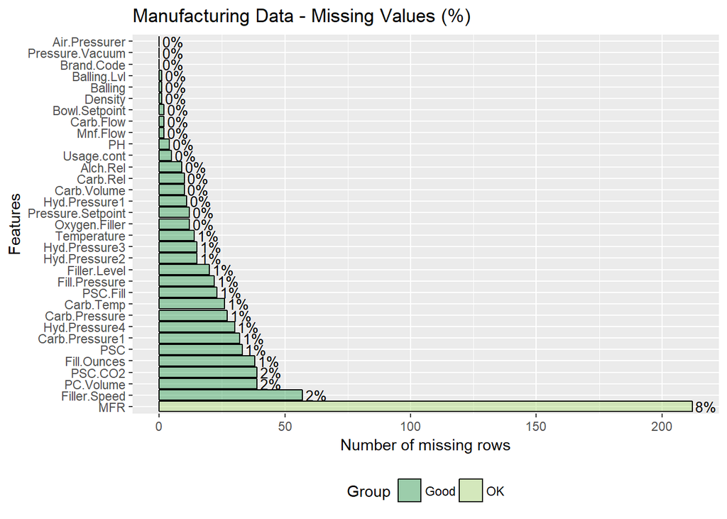

|  | x |
| --- | --- |
| Brand.Code | 0 |
| Carb.Volume | 10 |
| Fill.Ounces | 38 |
| PC.Volume | 39 |
| Carb.Pressure | 27 |
| Carb.Temp | 26 |
| PSC | 33 |
| PSC.Fill | 23 |
| PSC.CO2 | 39 |
| Mnf.Flow | 2 |
| Carb.Pressure1 | 32 |
| Fill.Pressure | 22 |
| Hyd.Pressure1 | 11 |
| Hyd.Pressure2 | 15 |
| Hyd.Pressure3 | 15 |
| Hyd.Pressure4 | 30 |
| Filler.Level | 20 |
| Filler.Speed | 57 |
| Temperature | 14 |
| Usage.cont | 5 |
| Carb.Flow | 2 |
| Density | 1 |
| MFR | 212 |
| Balling | 1 |
| Pressure.Vacuum | 0 |
| PH | 4 |
| Oxygen.Filler | 12 |
| Bowl.Setpoint | 2 |
| Pressure.Setpoint | 12 |
| Air.Pressurer | 0 |
| Alch.Rel | 9 |
| Carb.Rel | 10 |
| Balling.Lvl | 1 |

```
## # A tibble: 5 x 33
##   Brand.Code Carb.Volume Fill.Ounces PC.Volume Carb.Pressure Carb.Temp
##   <fct>            <int>       <int>     <int>         <int>     <int>
## 1 ""                   0           4         4             1         3
## 2 A                    0           8         7             2         1
## 3 B                    5          16        17            10        15
## 4 C                    1           4         4             2         2
## 5 D                    4           6         7            12         5
## # ... with 27 more variables: PSC <int>, PSC.Fill <int>, PSC.CO2 <int>,
## #   Mnf.Flow <int>, Carb.Pressure1 <int>, Fill.Pressure <int>,
## #   Hyd.Pressure1 <int>, Hyd.Pressure2 <int>, Hyd.Pressure3 <int>,
## #   Hyd.Pressure4 <int>, Filler.Level <int>, Filler.Speed <int>,
## #   Temperature <int>, Usage.cont <int>, Carb.Flow <int>, Density <int>,
## #   MFR <int>, Balling <int>, Pressure.Vacuum <int>, PH <int>,
## #   Oxygen.Filler <int>, Bowl.Setpoint <int>, Pressure.Setpoint <int>,
## #   Air.Pressurer <int>, Alch.Rel <int>, Carb.Rel <int>, Balling.Lvl <int>
```

```
##
##         A    B    C    D
##  120  293 1239  304  615
```

We have a number of missing values. Presumably, because we have identified NA values across various brands, both named and unnamed, we would expect that the NA values are not informative. In other words, if information for a particular brand is usually recorded, we would expect failure to record information to be the result of an error and not a typical process change for a particular brand. As our knowledge of the production process itself is limited, we will rely on your subject matter expertise to let us know if this presumption is incorrect.

MFR stands out as a variable with a significant number of missing values; however, the percentage of missing values is still low enough where imputation is not unreasonable. We will likely find it necessary to drop the few observations that have an NA value for the response variable.

## Descriptive Statistics and Data Exploration

Descriptive statistics was performed for all predictor and response variables to explore the data.

```
##                   vars    n    mean      sd  median trimmed    mad     min
## Brand.Code*          1 2571    3.39    1.11    3.00    3.42   1.48    1.00
## Carb.Volume          2 2561    5.37    0.11    5.35    5.37   0.11    5.04
## Fill.Ounces          3 2533   23.97    0.09   23.97   23.98   0.08   23.63
## PC.Volume            4 2532    0.28    0.06    0.27    0.27   0.05    0.08
## Carb.Pressure        5 2544   68.19    3.54   68.20   68.12   3.56   57.00
## Carb.Temp            6 2545  141.09    4.04  140.80  140.99   3.85  128.60
## PSC                  7 2538    0.08    0.05    0.08    0.08   0.05    0.00
## PSC.Fill             8 2548    0.20    0.12    0.18    0.18   0.12    0.00
## PSC.CO2              9 2532    0.06    0.04    0.04    0.05   0.03    0.00
## Mnf.Flow            10 2569   24.57  119.48   65.20   21.07 169.02 -100.20
## Carb.Pressure1      11 2539  122.59    4.74  123.20  122.54   4.45  105.60
## Fill.Pressure       12 2549   47.92    3.18   46.40   47.71   2.37   34.60
## Hyd.Pressure1       13 2560   12.44   12.43   11.40   10.84  16.90   -0.80
## Hyd.Pressure2       14 2556   20.96   16.39   28.60   21.05  13.34    0.00
## Hyd.Pressure3       15 2556   20.46   15.98   27.60   20.51  13.94   -1.20
## Hyd.Pressure4       16 2541   96.29   13.12   96.00   95.45  11.86   52.00
## Filler.Level        17 2551  109.25   15.70  118.40  111.04   9.19   55.80
## Filler.Speed        18 2514 3687.20  770.82 3982.00 3919.99  47.44  998.00
## Temperature         19 2557   65.97    1.38   65.60   65.80   0.89   63.60
## Usage.cont          20 2566   20.99    2.98   21.79   21.25   3.19   12.08
## Carb.Flow           21 2569 2468.35 1073.70 3028.00 2601.14 326.17   26.00
## Density             22 2570    1.17    0.38    0.98    1.15   0.15    0.24
## MFR                 23 2359  704.05   73.90  724.00  718.16  15.42   31.40
## Balling             24 2570    2.20    0.93    1.65    2.13   0.37   -0.17
## Pressure.Vacuum     25 2571   -5.22    0.57   -5.40   -5.25   0.59   -6.60
## PH                  26 2567    8.55    0.17    8.54    8.55   0.18    7.88
## Oxygen.Filler       27 2559    0.05    0.05    0.03    0.04   0.02    0.00
## Bowl.Setpoint       28 2569  109.33   15.30  120.00  111.35   0.00   70.00
## Pressure.Setpoint   29 2559   47.62    2.04   46.00   47.60   0.00   44.00
## Air.Pressurer       30 2571  142.83    1.21  142.60  142.58   0.59  140.80
## Alch.Rel            31 2562    6.90    0.51    6.56    6.84   0.06    5.28
## Carb.Rel            32 2561    5.44    0.13    5.40    5.43   0.12    4.96
## Balling.Lvl         33 2570    2.05    0.87    1.48    1.98   0.21    0.00
##                       max   range  skew kurtosis    se     IQR    Q0.1
## Brand.Code*          5.00    4.00  0.04    -0.61  0.02    1.00    2.00
## Carb.Volume          5.70    0.66  0.39    -0.47  0.00    0.16    5.25
## Fill.Ounces         24.32    0.69 -0.02     0.86  0.00    0.11   23.87
## PC.Volume            0.48    0.40  0.34     0.67  0.00    0.07    0.21
## Carb.Pressure       79.40   22.40  0.18    -0.01  0.07    5.00   63.80
```

[output cut: 47 more lines]

```
## Temperature         65.20   66.40   67.40
## Usage.cont          18.36   23.75   24.02
## Carb.Flow         1144.00 3186.00 3308.40
## Density              0.90    1.62    1.74
## MFR                706.30  731.00  735.80
## Balling              1.50    3.29    3.59
## Pressure.Vacuum     -5.60   -5.00   -4.40
## PH                   8.44    8.68    8.76
## Oxygen.Filler        0.02    0.06    0.10
## Bowl.Setpoint      100.00  120.00  120.00
## Pressure.Setpoint   46.00   50.00   50.00
## Air.Pressurer      142.20  143.00  143.60
## Alch.Rel             6.54    7.24    7.72
## Carb.Rel             5.34    5.54    5.62
## Balling.Lvl          1.38    3.14    3.32
```

We have siginificant skewness in a number of variables, and, depending on our choice of regression technique may require transformation.

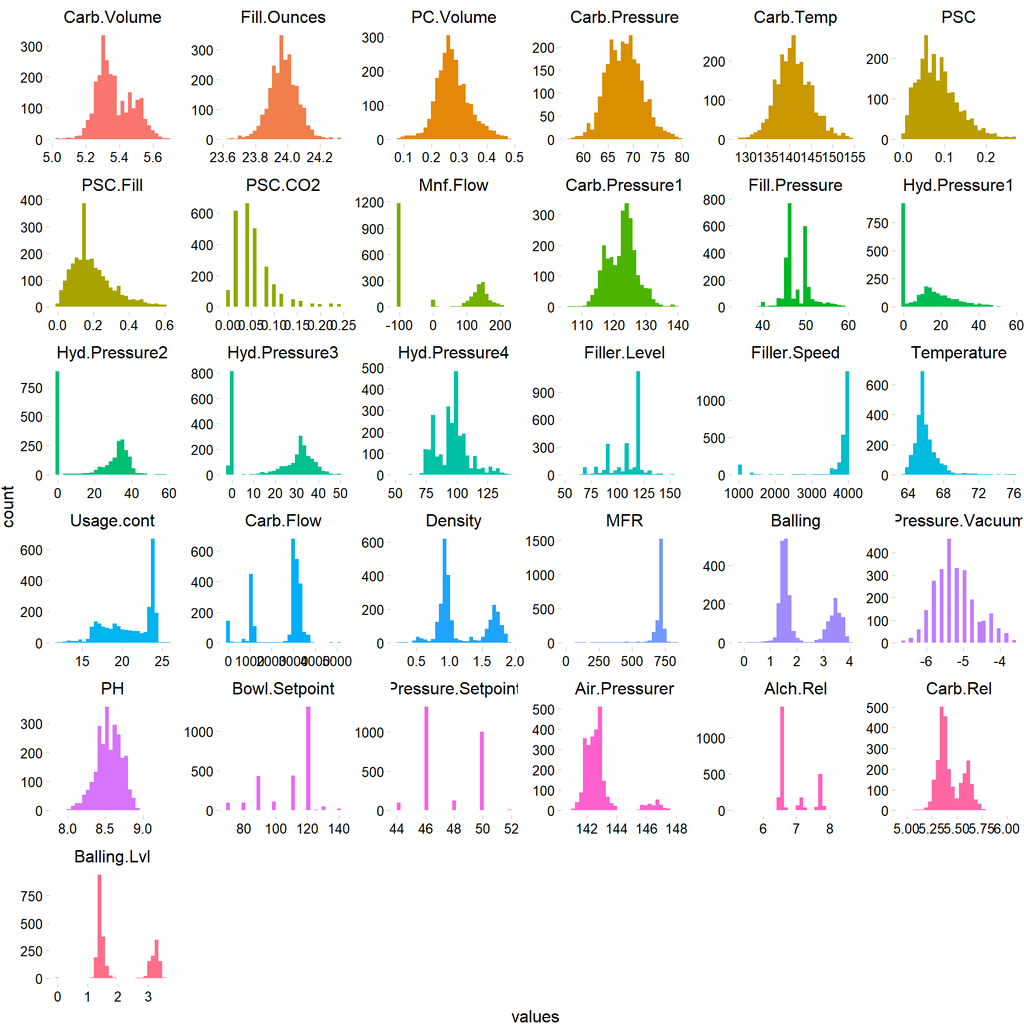

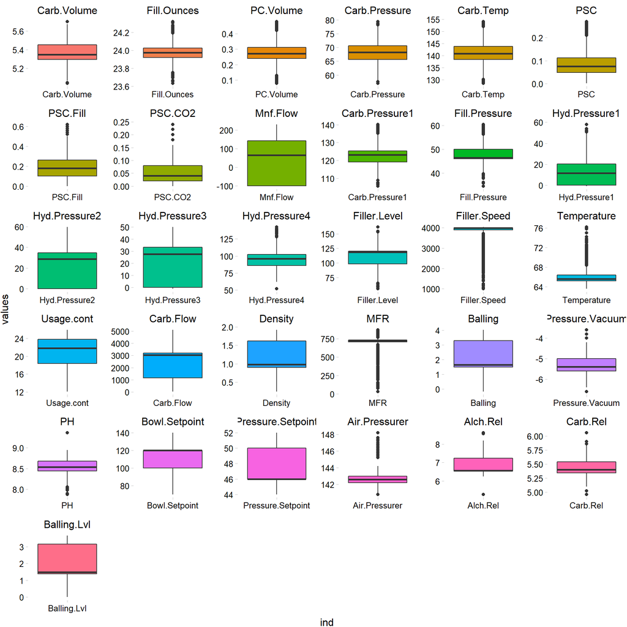

Ther boxplots above demonstrate the skewness of a number of variables as we have discussed.

Below is a look at the unique values for each variable. As mentioned, it appears that some of these variables represent various non continuous settings.

```
##        Brand.Code       Carb.Volume       Fill.Ounces         PC.Volume
##                 5               102                93               455
##     Carb.Pressure         Carb.Temp               PSC          PSC.Fill
##               107               124               130                33
##           PSC.CO2          Mnf.Flow    Carb.Pressure1     Fill.Pressure
##                14               488               141               109
##     Hyd.Pressure1     Hyd.Pressure2     Hyd.Pressure3     Hyd.Pressure4
##               246               208               193                41
##      Filler.Level      Filler.Speed       Temperature        Usage.cont
##               289               245                57               482
##         Carb.Flow           Density               MFR           Balling
##               534                79               588               218
##   Pressure.Vacuum                PH     Oxygen.Filler     Bowl.Setpoint
##                16                53               339                12
## Pressure.Setpoint     Air.Pressurer          Alch.Rel          Carb.Rel
##                 9                32                54                43
##       Balling.Lvl
##                83
```

## Recode Predictors

Creating simple dummy variables for the brand

```
##        Brand.Code       Carb.Volume       Fill.Ounces         PC.Volume
##          "factor"         "numeric"         "numeric"         "numeric"
##     Carb.Pressure         Carb.Temp               PSC          PSC.Fill
##         "numeric"         "numeric"         "numeric"         "numeric"
##           PSC.CO2          Mnf.Flow    Carb.Pressure1     Fill.Pressure
##         "numeric"         "numeric"         "numeric"         "numeric"
##     Hyd.Pressure1     Hyd.Pressure2     Hyd.Pressure3     Hyd.Pressure4
##         "numeric"         "numeric"         "numeric"         "integer"
##      Filler.Level      Filler.Speed       Temperature        Usage.cont
##         "numeric"         "integer"         "numeric"         "numeric"
##         Carb.Flow           Density               MFR           Balling
##         "integer"         "numeric"         "numeric"         "numeric"
##   Pressure.Vacuum                PH     Oxygen.Filler     Bowl.Setpoint
##         "numeric"         "numeric"         "numeric"         "integer"
## Pressure.Setpoint     Air.Pressurer          Alch.Rel          Carb.Rel
##         "numeric"         "numeric"         "numeric"         "numeric"
##       Balling.Lvl
##         "numeric"
```

## Transformation

The tables below represent correlation between response and predictor variables. There is high collinearity among certain variables. For instance in Density and Alch.Rel. This is also true of Alch.Res and Brand D.

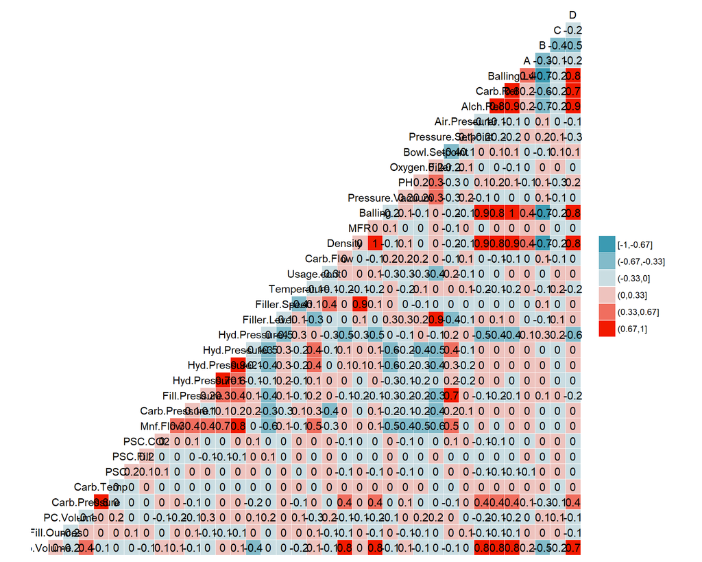

# Model 1